# Uczenie Statystyczne w R

Joanna Podsiadło i Aleksandra Pachołek

2020-04-09

# Cel projektu

Celem niniejszego projektu jest analiza danych dotyczących katastrofy wycieczkowca Titanic, do której doszło 1912 r. Analiza ta ma służyć budowie modelu predykcyjnego, który odpowie na pytanie: „Jakie czynniki wpłynęły na przeżycie katastrofy Titanica?”.

W projekcie opisany i przestawiony zostanie proces analizy i obróbki danych wejściowych, modelowania oraz walidacji modelu. Użyte i porównane zostaną różne techniki uczenia statystycznego:

- algorytm KNN,
- lasy losowe,
- regresja logistyczna
- oraz maszyna wektorów nośnych.

# Dane

Pakiet zawierający dane o katastrofie należy do jednego z najczęściej używanych przykładowych pakietów i jest łatwo dostępny w internecie. Zawiera on następujące zmienne :

- PassangerId - unikalny identyfikator nadany pasażerowi w celu ułatwienia analizy,
- Surivied - zmienna binarna informująca o tym, czy pasażer przeżył (0- pasażer nie przeżył, 1 - pasażer przeżył)
- Pclass - określenie klasy, w której znajdowało się miejsce wykupione przez pasażera,
- Name - imię i nazwisko pasażera,
- Sex - zmienna kategoryczna określająca płeć (male - jesli pasażer to mężczyzna, female- jeśli pasażer to kobieta)
- Age - wiek pasażera w latach,
- SibSp - liczba rodzeństwa i małżonków na pokładzie,
- Parch - liczba rodziców i dzieci na pokładzie,
- Ticket - numer biletu,
- Fare - cena biletu,
- Cabin - określenie kabiny, w której przebywał pasażer,
- Embarked - port, w którym pasażer wsiadł na pokład (S- Southamption, Q- Queenstown, C- Cherbourg)

Przedstawiają się one następująco:

| X | Survived | Age | Fare | Pclass | Sex | SibSp | Parch | Embarked | family_member_no |
| --- | --- | --- | --- | --- | --- | --- | --- | --- | --- |
| 1 | No | 30 | 22 | 2 | male | 0 | 0 | S | 0 |
| 2 | No | 27 | 181 | 3 | male | 0 | 0 | S | 0 |
| 3 | No | 19 | 193 | 3 | male | 0 | 0 | S | 0 |
| 4 | No | 32 | 68 | 3 | female | 0 | 4 | S | 4 |
| 5 | No | 36 | 141 | 1 | male | 1 | 0 | S | 1 |
| 6 | No | 45 | 198 | 3 | male | 2 | 0 | S | 2 |

W pierwszym kroku wybrano zmienne, które logicznie mogą mieć związek z katastrofą. Wyłaczono więc z dalszej analizy zmienne Ticket, PassangerId, Name.

## Analiza opisowa

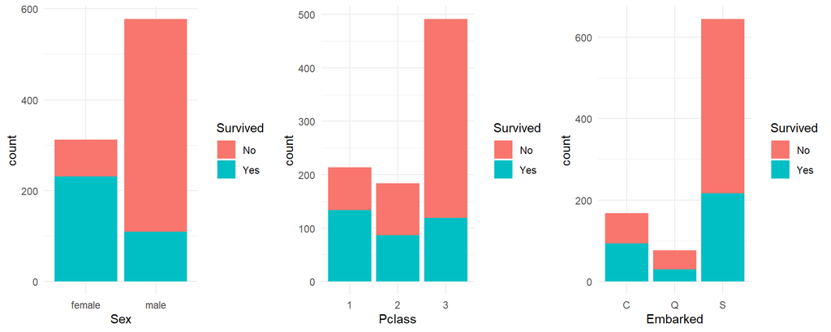

Na podstawie powyższych wykresów można zformułować następujące wnioski:

**Sex**

Na pokładzie była, prawie dwukrotnie większa liczba meżczyzn niz kobiet, jednak katastrofę przezylo ponad 200 kobiet i niewiele ponad 100 meżczyzn, powodem zapewne jest fakt, iż kobiety miały pierwszeństwo miejsca w dostępnym szalupach. Zatem można wywnioskować, ze kobiety miały większe prawdopodobieństwo przeżycia niż mężczyzni.

**Class**

Najwięcej osób podróżowało klasą 3 (prawie 500 osob) z czego około sto osób przeżylo katastrofę. Dla porownania klasą 1 podróżowało nieco ponad 200 osób i prawie 150 osob przeżyło. Można zauważyć, ze pódróżowanie pierwszą klasą zwiększa prawdopodobieństwo przeżycia.

**Embarked**

Na podstawie wykresu można wywnioskować, że najmniejsze szanse na przeżycie miały osoby wsiadajace w porcie Southampton, ponieważ katastrofę przeżyło ok. 30%, tam też najwiecej osób dołączyło do rejsu, bo aą ponad 600. Najkorzystniejszym portem był Cherbourg, bo stamtąd ponad połowa osób przeżyła.

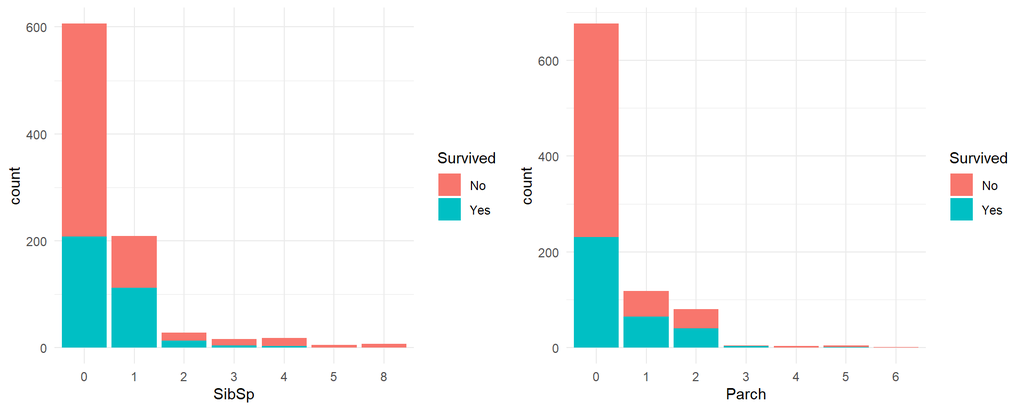

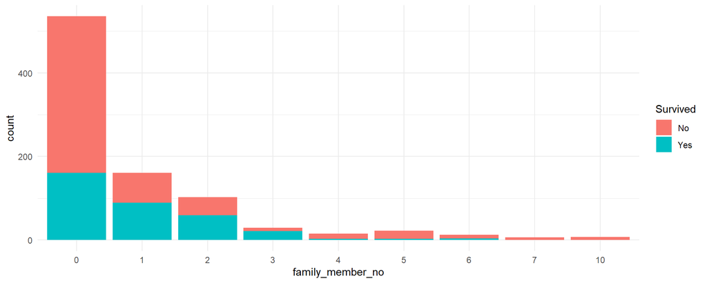

**SibSp i Parch**

Istotną rolę w katastrofie odgrywała obecność bliskich na pokładzie. Stąd została skonstruowana nowa zmienna wyrażająca liczbę bliskich na pokładzie. Widać, że praktycznie wszystkie osoby które miały więcej niż 4 bliskie osoby na pokładzie nie przeżyły katastrofy.

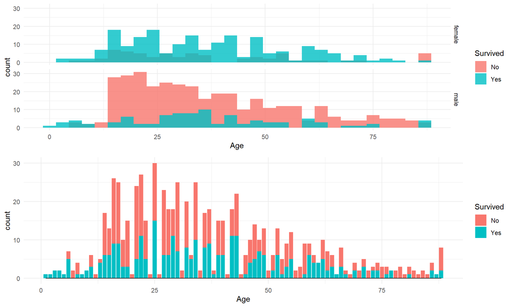

W zbiorze danych znajduja sie dwie zmienne ciagle.

**Age**

Najwięcej podróżujących mieściło się w przedziale wiekowym od 22 do 49 lat. Średnia wieku wynosiła 37 lat. Ciekawą zależność widać dla najstarszych kobiet na pokładzie, dla kazdej grupy wiekowej ponad polowa kobiet przeżyła katastrofę natomiast dla tej grupy spośród 5 kobiet przeżyła tylko jedna. W grupie mężczyzn od 15 do 60 lat większośćc nie przeżyła katastrofy. Stąd można wnioskowac, że są to osoby w sile wieku, ktore skupiły się na ratowaniu dzieci i kobiet.

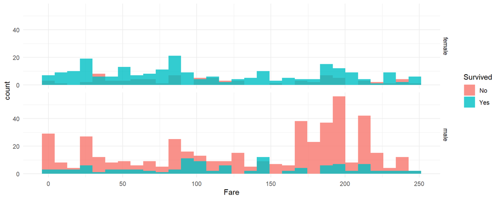

**Fare**

Cena biletów nie powinna wpływać na prawdopodobieństwo przeżycia aczkolwiek, widać ze najwięcej meżczyzn zginęło, jeżeli kupiło bilet w cenie od 160 do 220.

**Noble**

Dodadkowo utworzono jeszcze jedną zmienną, która na podstawie tytułów znajdujących się w zmiennej Name m.in. takich jak “Lady”,“Sir”, określa czy osoba ta posiadała wyższy status społeczny. Zmienną tą nazwano Noble, przyjmuje ona wartości 1 - jeśli osoba posiadała tytuł świadczący o wyższym statusie społeczym oraz 0, gdsy go nie posiadała.

## Dane brakujace

Ilość występujących braków w danych zebrano i przedstawiono w tabeli:

| Survived | Pclass | Name | Sex | Age | SibSp | Parch | Ticket | Fare | Cabin | Embarked | Noble |
| --- | --- | --- | --- | --- | --- | --- | --- | --- | --- | --- | --- |
| 0 | 0 | 0 | 0 | 177 | 0 | 0 | 0 | 0 | 687 | 2 | 0 |

## Przygotowanie i agregacja danych

Po wstępnej analizie przystąpiono do przygotowania danych do modelowania. W tym celu wszystkie wartosci typu “yes” i “no” zostana zamienione na binarne. Następnie dokonano podziału danych na zbiór treningowy i testowy w proporcji 80/20.

## Uzupełnienie braków i usunięcie wartości odstających

Wykres po lewej stronie przedstawia wartości zmiennej Age przed imputacją, natomiast wykres po prawej po imputacji. Widać że rozkłady zachowały swój kształt, zatem przekształcenie nie powinno wpłynac na jakość predykcji, a tym sposobem uniknięto dużej utraty obserwacji. Ponad to, ze zbioru testowego zostają usunięte obserwacje zawierające brakujące wartości.

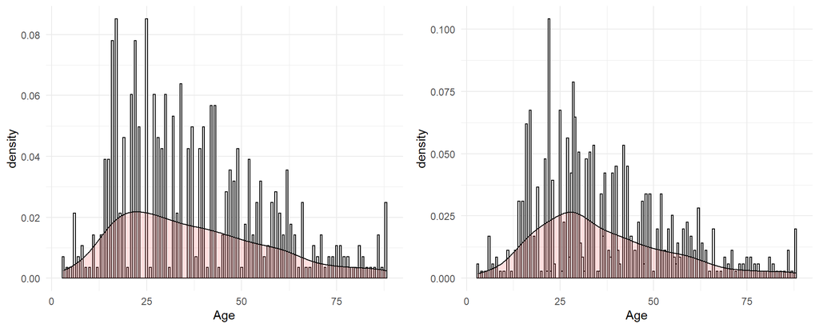

Na ponizszym wykresie przyjęto oznaczenia:

- 0-mężczyźni
- 1-kobiety.

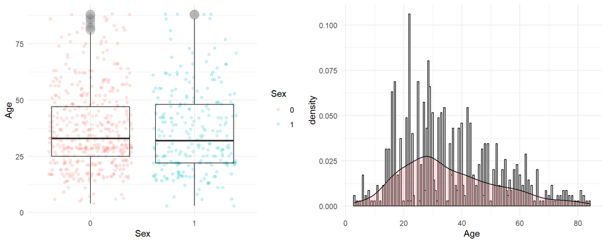

# Modelowanie

Dla każdej stosowanej metody budwy modelu prdykcyjnego (kNN, lasy losowe, regresja logistyczna, SVM) przedstawiono najlepszy z uzyskanych modeli a wraz z nimi parametry i wykresy mające służyć ich ocenie. Są to:

- **Dokładność predykcji** (ACC) - odsetek poprawnych klasyfikacji,
- **Macierz pomyłek** (confusion matrix) - buduje się ja na podstawie zestawienia ze sobą wartości predykcji dla danych testowych na podstawie modelu i wartości rzeczywistych zmiennej objaśnianej ze zbioru testowego (Survived). Macierz daje informacje o obiektach, które są TP (true positive pasażerowie, którzy przeżyli i model zaklasyfikował ich poprawnie), TN (true negative pasażerowie, którzy nie przeżyli i model zaklasyfikował ich poprawnie), FP (false positive – pasażerowie, którzy nieprzeżyli, a model zaklasyfikował, że przeżyli) i FN (false negative – osoby, które nieprzeżyły, a model zaklasyfikował, że przeżyły).
- **Czułość** (sensivity) = TP/(TP+FN)
- **Specyficzność** (specivity) =TN/(TN+FP)
- **Krzywa ROC**, która powstaje poprzez obliczenie wartosci funkcji decyzyjnej. Testujemy uzyskany klasyfikator dla różnych progów alfa (alfa jest to próg szacowanego pradopodobieństwa, powyżej którego obserwacja klasyfikowana jest do jednej kategorii, a poniżej do drugiej). Z każdej klasyfikacji otrzymujemy parę TPR i FPR, która jest pojedynczym punktem dla krzywej ROC. Im bardziej wpukły wykres krzywej ROC tym lepszy klasyfikator.
- **AUC** - pole pod krzywą ROC

## K-najbliższych sąsiadów

Algorytm kNN jest przykładem algorytmu uczenia nadzorowanego. Może zostać użyty zarówno do klasyfikacji, jak i regresji. Działa w oparciu o tezę mówiącą o tym, że podobne obiekty znajdują się blisko siebie. Na podstawie przyjętej miary odległości np. euklidesowej (można skorzystac z innych metryk np. odległosc Hamminga) dane są grupowane i następnie przydzielane do poszczególnych kategorii.

Macierz pomyłek - zbiór testowy:

|  | Did not survived | Survived |
| --- | --- | --- |
| Did not survived | 68 | 42 |
| Survived | 16 | 22 |

Krzywa ROC - zbiór testowy:

```
Call:
roc.default(response = as.vector(test$Survived), predictor = attributes(knn_model)$prob)

Data: attributes(knn_model)$prob in 84 controls (as.vector(test$Survived) 0) > 64 cases (as.vector(test$Survived) 1).
Area under the curve: 0.538
```

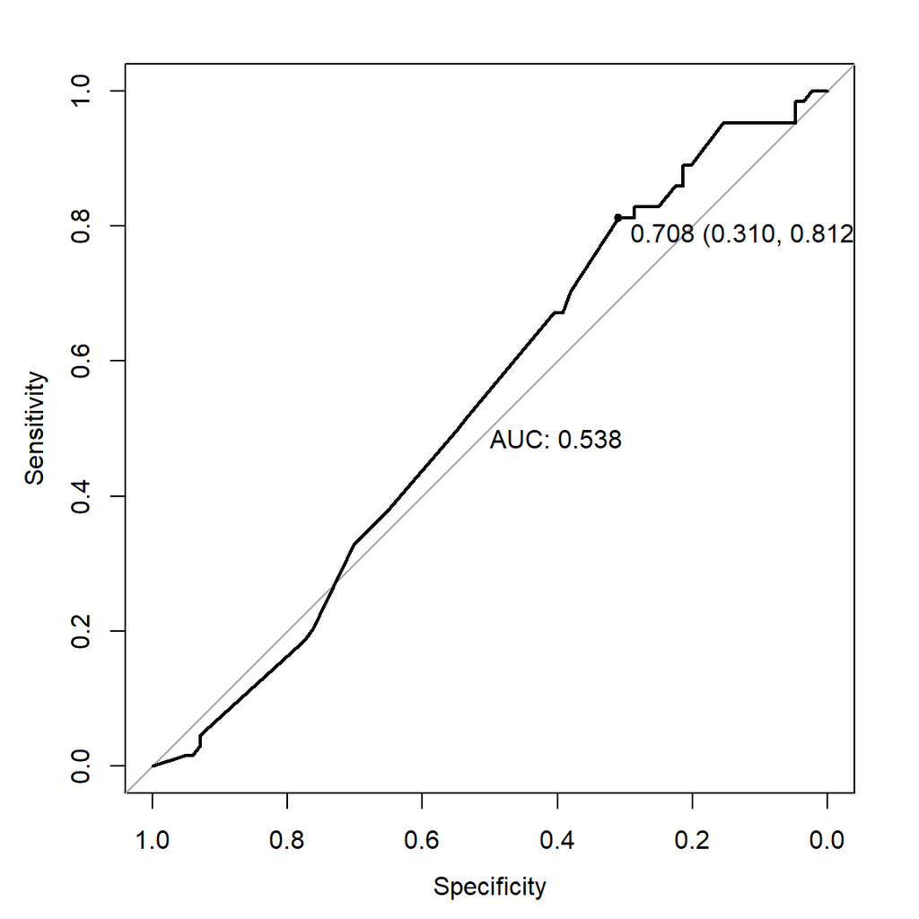

## Lasy losowe

Lasy losowe są algorytmem bazującym na drzewach losowych. Działają one poprzez zagregowanie predykcji obliczonych na podstawie wielu drzew. Każde drzewo decyzyjne w “lesie” jest trenowane na podzbiorze zbioru danych tzw. “bootstraped dataset”.

```
Call:
 randomForest(formula = Survived ~ ., data = train)
               Type of random forest: classification
                     Number of trees: 500
No. of variables tried at each split: 3

        OOB estimate of  error rate: 16.91%
Confusion matrix:
    0   1 class.error
0 395  39  0.08986175
1  79 185  0.29924242
```

```
                 MeanDecreaseGini
Age                     52.152511
Fare                    51.860415
Pclass                  28.097650
Sex                     83.250607
SibSp                    8.567300
Parch                    7.596234
Embarked                 9.536278
Noble                    0.000000
family_member_no        16.730774
```

Macierz pomyłek - zbiór treningowy:

|  | Did not survived | Survived |
| --- | --- | --- |
| Did not survived | 428 | 6 |
| Survived | 40 | 224 |

Krzywa ROC - zbiór treningowy:

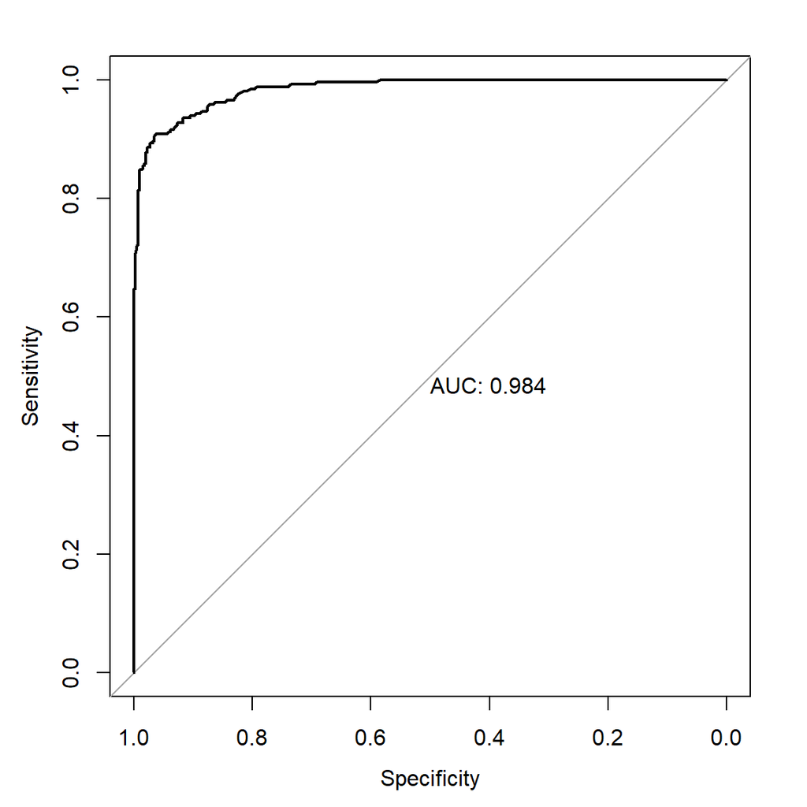

Macierz pomyłek - zbiór testowy:

|  | Did not survived | Survived |
| --- | --- | --- |
| Did not survived | 80 | 4 |
| Survived | 20 | 44 |

Krzywa ROC - zbiór testowy:

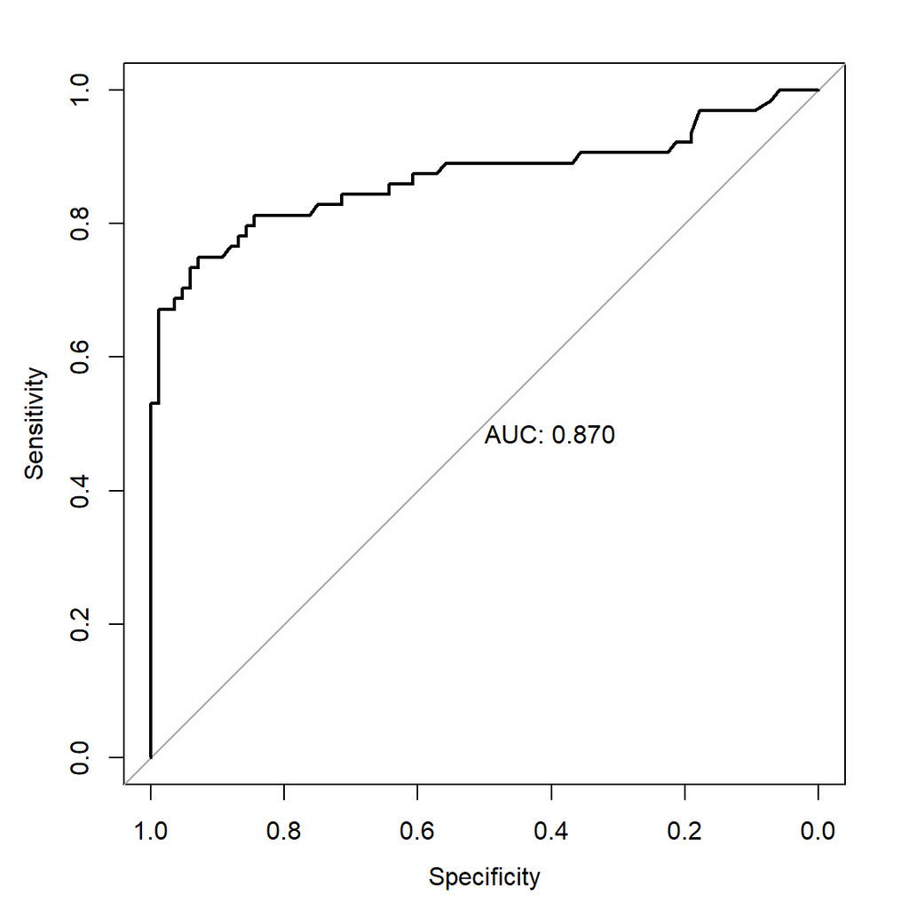

## Regresja logistyczna

Model regresji logistycznej jest szczególnym przypadkiem uogólnionego modelu liniowego. Znajduje zastosowanie, gdy zmienna zależna jest dychotomiczna, to znaczy przyjmuje tylko dwie wartości takie jak na przykład sukces lub porażka, wystąpienie lub brak pewnej jednostki chorobowej, kobieta lub mężczyzna. W zapisie matematycznym wartości te reprezentowane są jako 1 i 0.

W celu wybrania odpowiedniej postaci modely regresji logistycznej przetestowano różne kombinację zmiennych. Przy wyborze ostatecznej postaci wzięto pod uwagę istotność statystyczną zmiennych oraz kryterium informacyjne AIC (im niższe tym model lepszy). Ostatecznie jako zmienne objaśniające wybrano: Age, Sex, Pclass oraz Embarked. Wyniki przestawiają się następująco:

```
Call:
glm(formula = Survived ~ Age + Sex + Pclass + Embarked, family = "binomial",
    data = train)

Deviance Residuals:
    Min       1Q   Median       3Q      Max
-2.3391  -0.6498  -0.4164   0.6532   2.4006

Coefficients:
            Estimate Std. Error z value Pr(>|z|)
(Intercept)  1.77127    0.46609   3.800 0.000145 ***
Age         -0.01689    0.00655  -2.579 0.009900 **
Sex          2.70698    0.21295  12.712  < 2e-16 ***
Pclass      -1.08028    0.13886  -7.780 7.27e-15 ***
Embarked    -0.21258    0.12442  -1.709 0.087539 .
---
Signif. codes:  0 '***' 0.001 '**' 0.01 '*' 0.05 '.' 0.1 ' ' 1

(Dispersion parameter for binomial family taken to be 1)

    Null deviance: 925.81  on 697  degrees of freedom
Residual deviance: 627.68  on 693  degrees of freedom
AIC: 637.68

Number of Fisher Scoring iterations: 5
```

Macierz pomyłek - zbiór treningowy:

|  | Did not survived | Survived |
| --- | --- | --- |
| Did not survived | 370 | 64 |
| Survived | 75 | 189 |

Krzywa ROC - zbiór treningowy:

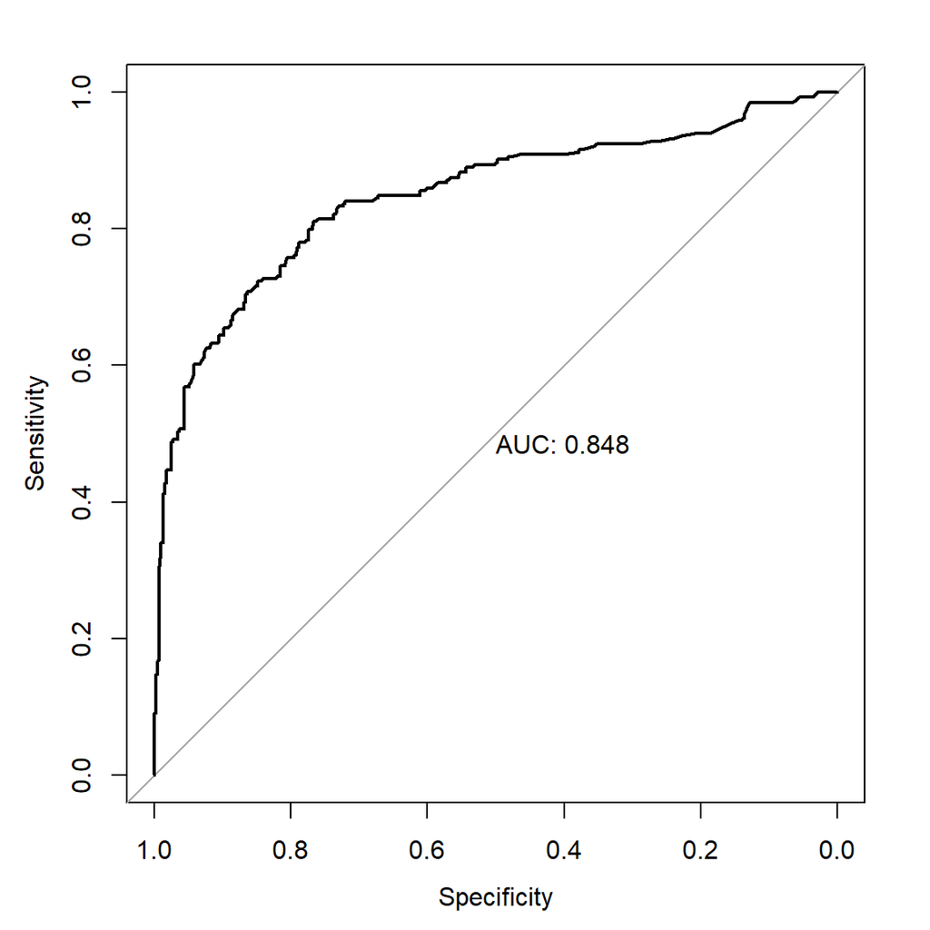

Macierz pomyłek - zbiór testowy:

|  | Did not survived | Survived |
| --- | --- | --- |
| Did not survived | 73 | 11 |
| Survived | 20 | 44 |

Krzywa ROC - zbiór testowy:

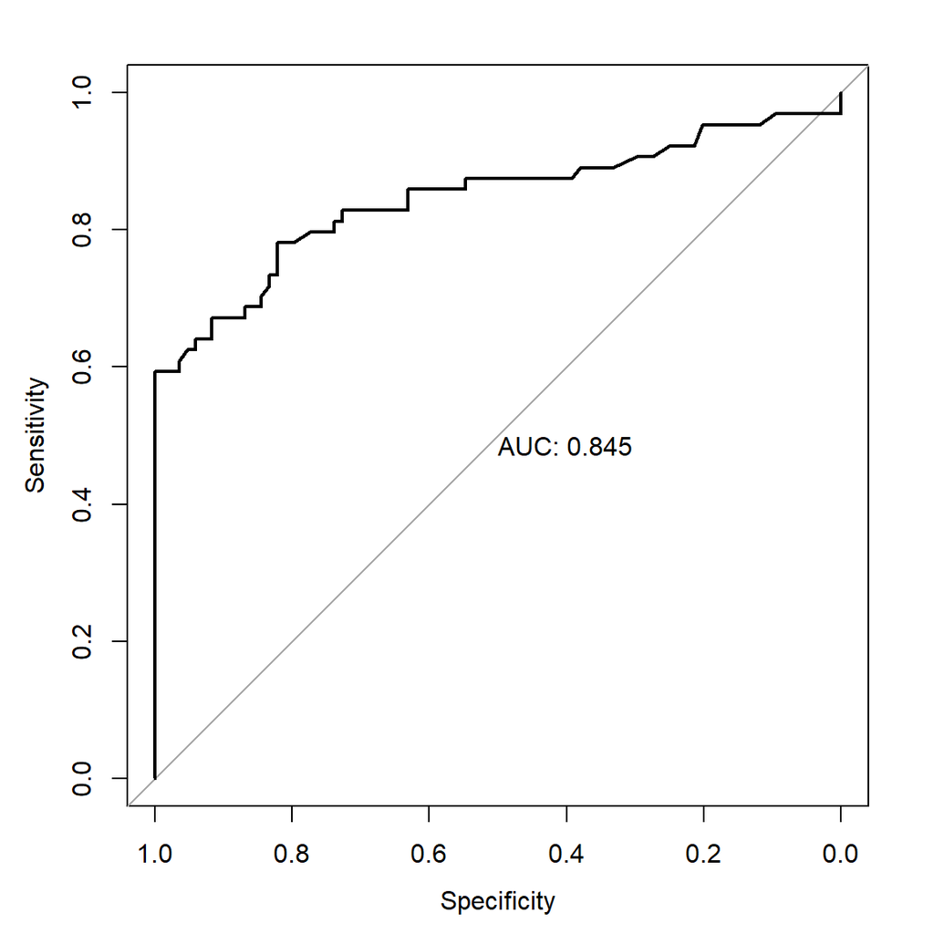

## SVM - Maszyna wektorów nośnych

Maszyna wektorów nośnych, SVM (ang. Support vector Machine) to w teorii uczenia maszynowego jeden z algorytmów uczenia nadzworowanego stosowany głównie do klasyfikacji. Maszyna wektorów nośnych stanowi abstrakcyjny koncept maszyny, która działa jak klasyfikator, a której nauka ma na celu wyznaczenie hiperpłaszczyzny rozdzielającej z maksymalnym marginesem przykłady należące do dwóch klas.

Macierz pomyłek - zbiór treningowy:

|  | Did not survived | Survived |
| --- | --- | --- |
| Did not survived | 369 | 65 |
| Survived | 81 | 183 |

Krzywa ROC - zbiór treningowy:

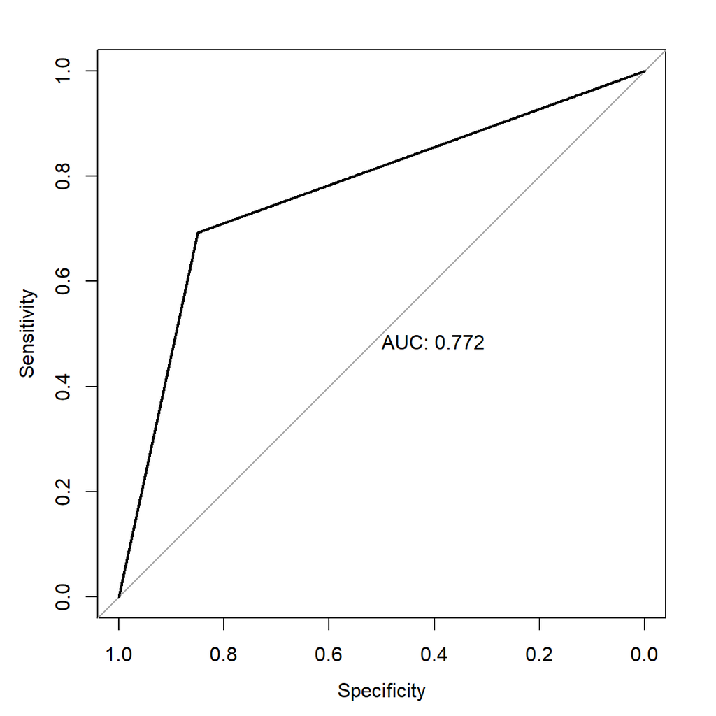

Macierz pomyłek -zbiór testowy:

|  | Did not survived | Survived |
| --- | --- | --- |
| Did not survived | 73 | 11 |
| Survived | 20 | 44 |

Krzywa ROC - zbiór testowy:

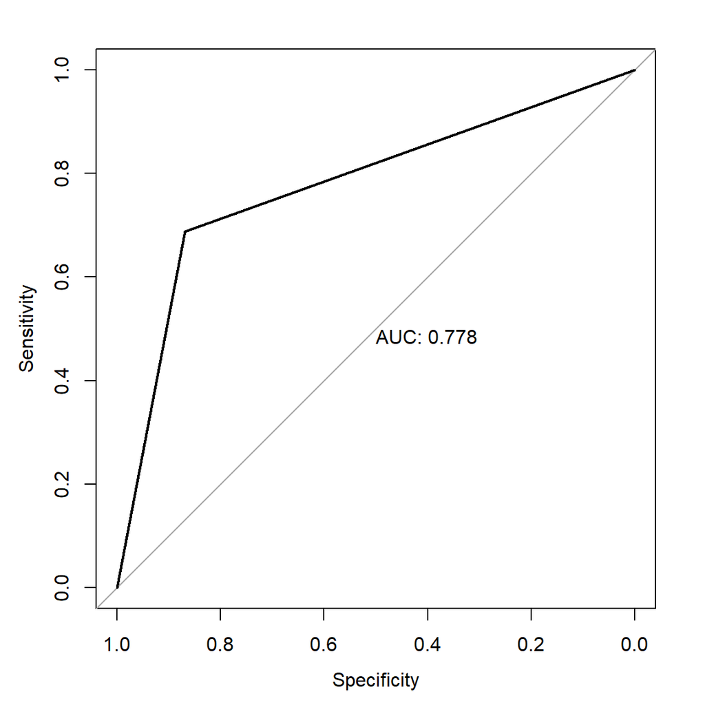

# Wybór najlepszego modelu

Na pierwszy rzut oka wybór najlepszego modelu, może wydawać się dosyć prostym zadaniem, ale w praktyce czasami jest to skomplikowany proces. Istnieje wiele różnych metod oceny modeli i wyboru najlepszego z nich. Często stosuje się techniki bazujące na porównawczej ocenie modeli (ang. competitive evaluation of models) polegającej na stosowaniu poszczególnych metod dla tych samych zbiorów danych, a następnie wybraniu najlepszej z nich lub zbudowaniu modelu złożonego. Właśnie tą metodą posłużono się w tej pracy. Poniżej zebrano wartości wybranych wskaźników obliczonych dla poszczególnych modeli.

**ACC**:

[output not shown]

**AUC, czułość i specyficzność - zbiór treningowy**:

[output not shown]

**AUC, czułość i specyficzność - zbiór testowy**:

[output not shown]

Analizując wyniki zestawione w tabelach mozemy bez wachania wytypować model zbudowany przy pomocy algorytmu random forest jako najlepszy spośród modeli.

# Doskonalenie modelu

Model predykcyjny uzyskany po zastosowaniu algorytmu lasów losowych został wytypowany jako najlepszy, dlatego też postanowiono podjąć próbę zwiększenia jakości predykcji poprzez udoskonalenie tego modelu. W tym celu użyto bardziej zaawansowanych technik takich jak tuning hiperparametrów i sprawdzian krzyżowy.

Hiperparametry są to parametry konfigurowane przez twórców modelu np. liczba lasów w lesie losowym lub ilość grup w algorytmie KNN. Odpowiedni dobór hiperparametrów może zwiększyć skuteczność zbudowanego modelu.

W celu zapewnienia lepszego podziału próby statystycznej na podzbiory użyty został sprawdzian krzyżowy z k-krotną walidacją. Oryginalna próba dzielona jest na k podzbiorów. Następnie każdy z podzbiorów służy jako zbiór testowy, a pozostałe zsumowane tworzą zbiór uczący i wykonywana jest analiza. Tym sposobem analiza jest wykonywana k razy. Następnie poprzez uśrednienie wszystkich k rezultatów uzyskiwana jest dokładność modelu. Dzięki tej metody można uniknąć nadmiernego dopasowania modelu i losowości z klasycznego podziału 80 do 20.

```
Random Forest

698 samples
  9 predictor
  2 classes: '0', '1'

Pre-processing: centered (9), scaled (9)
Resampling: Cross-Validated (10 fold, repeated 3 times)
Summary of sample sizes: 628, 629, 627, 628, 629, 629, ...
Resampling results across tuning parameters:

  mtry  Accuracy   Kappa
  2     0.8210124  0.6046662
  3     0.8200391  0.6051662
  4     0.8242985  0.6176057
  5     0.8146988  0.5996218
  6     0.8128209  0.5973760
  8     0.8104401  0.5930038

Accuracy was used to select the optimal model using the largest value.
The final value used for the model was mtry = 4.
```

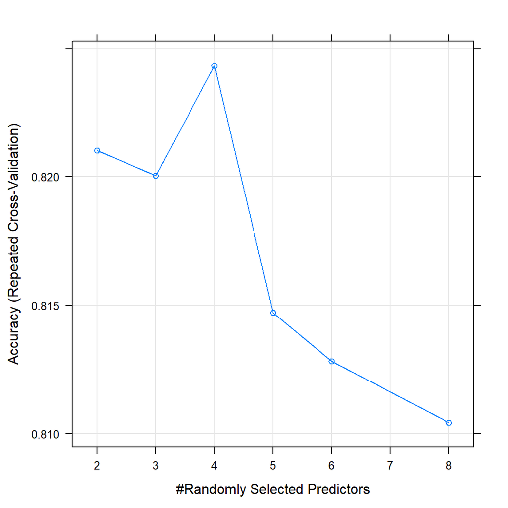

Macierz pomyłek - zbiór treninogwy:

|  | Did not survived | Survived |
| --- | --- | --- |
| Did not survived | 430 | 26 |
| Survived | 4 | 238 |

Macierz pomyłek - zbiór testowy:

```
rf_pred            Did not survived Survived
  Did not survived               80       19
  Survived                        4       45
```

ROC - zbiór treningowy:

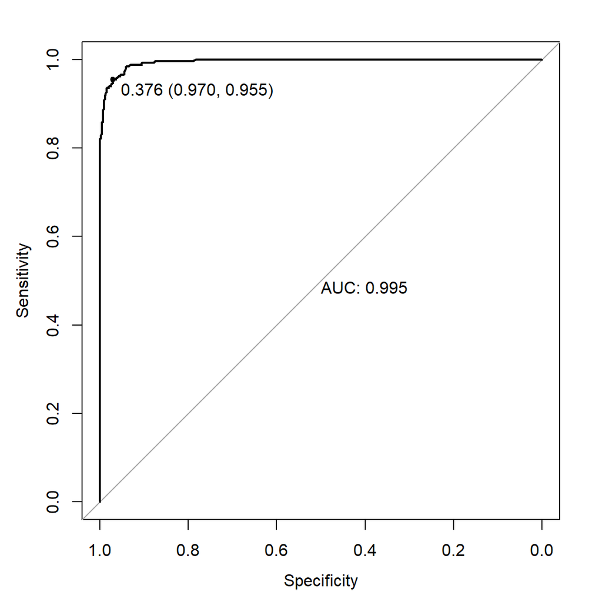

ROC - zbiór testowy:

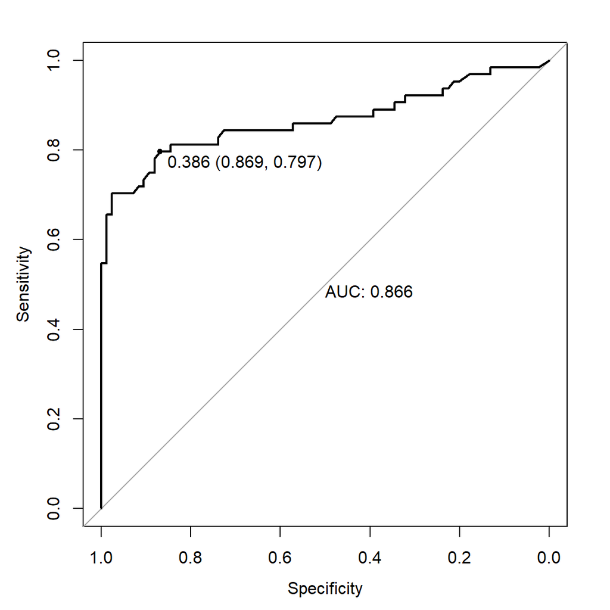

# Podsumowanie

Proces budowy modelu predykcyjnego ma często bardzo złożony charakter. Oddziaływanie szeregu różnorodnych czynników egzogenicznych oraz endogenicznych nie ułatwia znalezienia tego jedynego najwłaściwszego rozwiązania. Modele uczenia statystycznego stanowią niejednokrotnie dobre wyjście. Istotne jest odpowiednie przeprowadzenie poszczególnych etapów budowy modelu,gdyż od tego procesu zależy jakość osiąganych predykcji. W przypadku budowy modelu prognozującego przetrwanie na statku Titanic, spośród czterech zaproponowanych rozwiązań najlepiej sprawdził się model lasów losowych (ang. random forest).